# Group 4 Assignment 4

### scree, cumulative variance plots

A better way to understand and then choose the appropriate number of principal components is to visualize the results using scree and cumulative variance plot. The scree plot (“elbow” method) would indicate that the first 4 components are the most important ones, although they merely captured roughly 32% of the variance in the data. The first 29 components have the standard deviation above 1 and together they captured 77% of the variance. The number of dimensions is significantly reduced from 91 to 29 in this case.

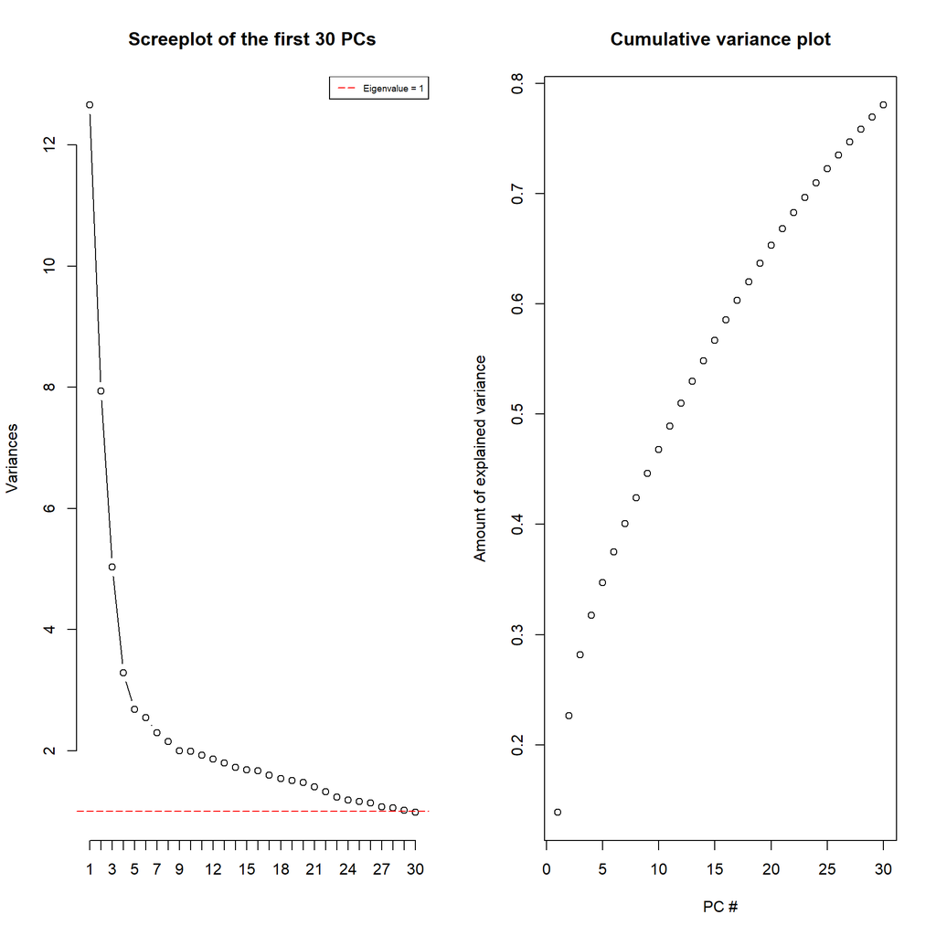

```r
par(mfrow = c(1, 2))

# scree plot
screeplot(adhdPCA, type = "l", npcs = 30, main = "Screeplot of the first 30 PCs")
abline(h = 1, col = "red", lty = 5)
legend("topright", legend = c("Eigenvalue = 1"), col = c("red"), lty = 5, cex = 0.6)

# cumulative variance plot
cumpro <- cumsum(adhdPCA$sdev^2 / sum(adhdPCA$sdev^2))
plot(cumpro[0:30], xlab = "PC #", ylab = "Amount of explained variance", main = "Cumulative variance plot")
```

### loadings

**loadings** reveal how our variables contribute to each principal component. Positive loadings indicate a variable and a principal component are positively correlated: an increase in one results in an increase in the other. Negative loadings indicate a negative correlation. Large (either positive or negative) loadings indicate that a variable has a strong effect on that principal component. Because the sum of the squares of all loadings for an individual principal component must sum to one, we can calculate what the loadings would be if all variables contributed equally to that principal component. Any variable that has a larger loading than this value contributes more than one variable’s worth of information and would be regarded as an important contributor to that principal component.

```r
cut_off <- sqrt(1/ncol(dfReady %>% dplyr::select(contains("adhd_"))))

loadingsDf <- loadings %>%
    as.data.frame() %>%
    tibble::rownames_to_column() %>%
    dplyr::select(variables = rowname, everything())

pc1_important <- loadingsDf %>%
    dplyr::filter(abs(PC1) > cut_off) %>%
    dplyr::select(variables, PC1) %>%
    arrange(desc(abs(PC1)))

pc1_important %>%
  kable() %>%
  scroll_box()
```

| variables | PC1 |
| --- | --- |
| adhd_total | -0.2799082 |
| adhd_q5_X4 | -0.1666408 |
| adhd_q10_X4 | -0.1591090 |
| adhd_q8_X4 | -0.1554668 |
| adhd_q9_X0 | 0.1552794 |
| adhd_q14_X4 | -0.1499107 |
| adhd_q12_X0 | 0.1483093 |
| adhd_q17_X0 | 0.1456655 |
| adhd_q15_X4 | -0.1451930 |
| adhd_q13_X4 | -0.1449852 |
| adhd_q7_X4 | -0.1446878 |
| adhd_q1_X0 | 0.1428465 |
| adhd_q16_X4 | -0.1399452 |
| adhd_q11_X4 | -0.1395682 |
| adhd_q14_X0 | 0.1385226 |
| adhd_q4_X0 | 0.1385106 |
| adhd_q4_X4 | -0.1375949 |
| adhd_q18_X0 | 0.1361917 |
| adhd_q10_X1 | 0.1338729 |
| adhd_q8_X0 | 0.1325776 |
| adhd_q2_X0 | 0.1302492 |
| adhd_q6_X0 | 0.1301560 |
| adhd_q3_X0 | 0.1278680 |
| adhd_q5_X0 | 0.1270487 |
| adhd_q9_X4 | -0.1268527 |
| adhd_q17_X4 | -0.1228279 |
| adhd_q6_X4 | -0.1217048 |
| adhd_q15_X0 | 0.1214741 |
| adhd_q7_X1 | 0.1212228 |
| adhd_q11_X0 | 0.1194972 |
| adhd_q18_X4 | -0.1173525 |
| adhd_q13_X1 | 0.1168028 |
| adhd_q2_X4 | -0.1155950 |
| adhd_q16_X0 | 0.1135285 |
| adhd_q8_X1 | 0.1132311 |
| adhd_q13_X0 | 0.1086601 |
| adhd_q1_X4 | -0.1085188 |
| adhd_q3_X4 | -0.1076261 |
| adhd_q7_X0 | 0.1062133 |
| adhd_q9_X3 | -0.1060439 |

```r
pc2_important <- loadingsDf %>%
    dplyr::filter(abs(PC2) > cut_off) %>%
    dplyr::select(variables, PC2) %>%
    arrange(desc(abs(PC2)))

pc2_important %>%
  kable() %>%
  scroll_box()
```

| variables | PC2 |
| --- | --- |
| adhd_q11_X0 | -0.1742647 |
| adhd_q4_X0 | -0.1599407 |
| adhd_q8_X0 | -0.1579807 |
| adhd_q14_X0 | -0.1549818 |
| adhd_q7_X0 | -0.1529713 |
| adhd_q18_X1 | 0.1516660 |
| adhd_q2_X4 | -0.1501502 |
| adhd_q5_X0 | -0.1497169 |
| adhd_q9_X0 | -0.1453479 |
| adhd_q1_X0 | -0.1449679 |
| adhd_q11_X4 | -0.1442962 |
| adhd_q6_X0 | -0.1424132 |
| adhd_q15_X0 | -0.1397099 |
| adhd_q10_X4 | -0.1390831 |
| adhd_q8_X4 | -0.1361637 |
| adhd_q12_X0 | -0.1354967 |
| adhd_q16_X4 | -0.1339139 |
| adhd_q12_X1 | 0.1333551 |
| adhd_q17_X0 | -0.1327396 |
| adhd_q10_X0 | -0.1315912 |
| adhd_q7_X4 | -0.1313751 |
| adhd_q13_X2 | 0.1301477 |
| adhd_q9_X1 | 0.1300177 |
| adhd_q10_X2 | 0.1298161 |
| adhd_q13_X0 | -0.1271095 |
| adhd_q15_X4 | -0.1268380 |
| adhd_q8_X2 | 0.1242382 |
| adhd_q18_X0 | -0.1238995 |
| adhd_q7_X2 | 0.1230813 |
| adhd_q18_X4 | -0.1228124 |
| adhd_q4_X4 | -0.1216899 |
| adhd_q4_X2 | 0.1204936 |
| adhd_q17_X2 | 0.1192034 |
| adhd_q9_X4 | -0.1189392 |
| adhd_q13_X4 | -0.1166796 |
| adhd_q11_X2 | 0.1162003 |
| adhd_q1_X4 | -0.1151128 |
| adhd_q15_X2 | 0.1144691 |
| adhd_q2_X0 | -0.1143741 |
| adhd_q3_X0 | -0.1134360 |
| adhd_q5_X3 | 0.1117895 |
| adhd_q17_X4 | -0.1108351 |
| adhd_q14_X4 | -0.1099284 |
| adhd_q14_X2 | 0.1096702 |
| adhd_q5_X4 | -0.1079195 |
| adhd_q16_X1 | 0.1071090 |

### biplot

The biplot displays the individuals and variables in the same plot featuring the first two principal components. It seems to suggest that the individuals can be visually clustered into 4 groups based on their responses to the ADHD questions.

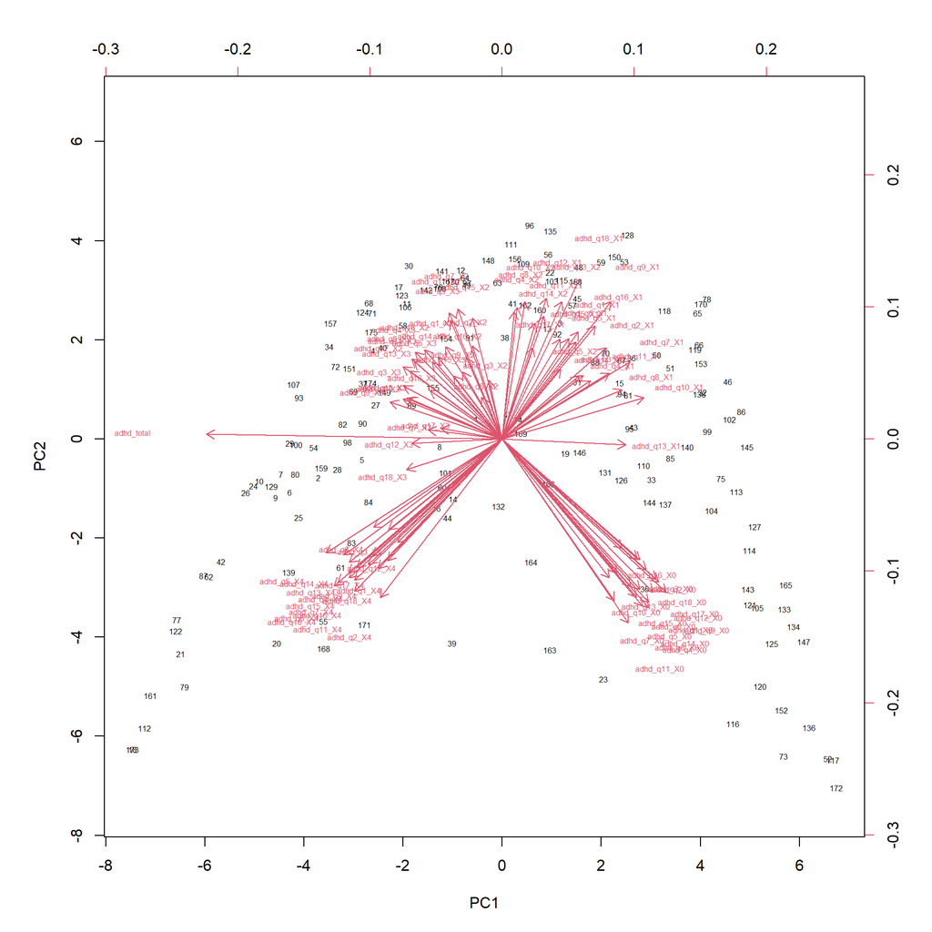

```r
biplot(adhdPCA, scale = 0, cex = 0.5)
```

## PCA - MD

### summary

We repeat a similar exercise for the MD questions. The summary suggested that the first four components (standard deviation above 1) would account for 61% of the total variance in the data.

```r
mdPCA <- prcomp(dfReady %>% dplyr::select(contains("md_")))
summary(mdPCA)
```

```
## Importance of components:
##                           PC1    PC2    PC3     PC4    PC5     PC6     PC7
## Standard deviation     2.6113 1.4086 1.2444 1.15095 0.9873 0.93176 0.88991
## Proportion of Variance 0.3589 0.1044 0.0815 0.06972 0.0513 0.04569 0.04168
## Cumulative Proportion  0.3589 0.4633 0.5448 0.61454 0.6658 0.71154 0.75322
##                           PC8    PC9    PC10    PC11    PC12    PC13    PC14
## Standard deviation     0.8282 0.7858 0.76010 0.72686 0.70223 0.69772 0.65510
## Proportion of Variance 0.0361 0.0325 0.03041 0.02781 0.02595 0.02562 0.02259
## Cumulative Proportion  0.7893 0.8218 0.85222 0.88003 0.90598 0.93160 0.95419
##                           PC15    PC16   PC17    PC18      PC19
## Standard deviation     0.57888 0.54077 0.4912 0.03918 3.919e-16
## Proportion of Variance 0.01764 0.01539 0.0127 0.00008 0.000e+00
## Cumulative Proportion  0.97183 0.98722 0.9999 1.00000 1.000e+00
```

```r
sd2 <- mdPCA$sdev
loadings2 <- mdPCA$rotation
rownames(loadings2) <- colnames(dfReady %>% dplyr::select(contains("md_")))
scores2 <- mdPCA$x
```

### scree, cumulative variance plots

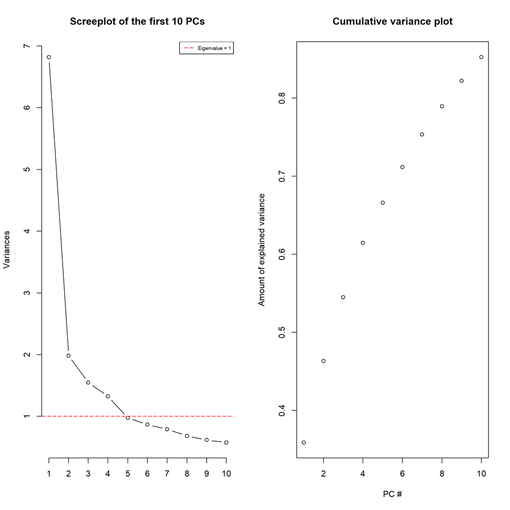

```r
par(mfrow = c(1, 2))

# scree plot
screeplot(mdPCA, type = "l", npcs = 10, main = "Screeplot of the first 10 PCs")
abline(h = 1, col = "red", lty = 5)
legend("topright", legend = c("Eigenvalue = 1"), col = c("red"), lty = 5, cex = 0.6)

# cumulative variance plot
cumpro <- cumsum(mdPCA$sdev^2 / sum(mdPCA$sdev^2))
plot(cumpro[0:10], xlab = "PC #", ylab = "Amount of explained variance", main = "Cumulative variance plot")
```

### loadings

Similar to ADHD set, **md_total** is the most important contributor to the first principal component.

```r
cut_off2 <- sqrt(1/ncol(dfReady %>% dplyr::select(contains("md_"))))

loadingsDf2 <- loadings2 %>%
    as.data.frame() %>%
    tibble::rownames_to_column() %>%
    dplyr::select(variables = rowname, everything())

pc1_important2 <- loadingsDf2 %>%
    dplyr::filter(abs(PC1) > cut_off2) %>%
    dplyr::select(variables, PC1) %>%
    arrange(desc(abs(PC1)))

pc1_important2 %>% kable() %>% scroll_box()
```

| variables | PC1 |
| --- | --- |
| md_total | -0.3810349 |
| md_q2_X1 | -0.2801951 |
| md_q1l_X1 | -0.2709416 |
| md_q1a_X1 | -0.2639121 |
| md_q1g_X1 | -0.2611799 |
| md_q1f_X1 | -0.2563764 |
| md_q1b_X1 | -0.2467297 |
| md_q1e_X1 | -0.2418589 |
| md_q1h_X1 | -0.2324126 |

```r
pc2_important2 <- loadingsDf2 %>%
    dplyr::filter(abs(PC2) > cut_off2) %>%
    dplyr::select(variables, PC2) %>%
    arrange(desc(abs(PC2)))

pc2_important2 %>% kable() %>% scroll_box()
```

| variables | PC2 |
| --- | --- |
| md_q3_X3 | -0.4708997 |
| md_q1h_X1 | 0.3504518 |
| md_q1j_X1 | 0.3150925 |
| md_q1k_X1 | 0.2944976 |
| md_q1i_X1 | 0.2872030 |
| md_q1c_X1 | 0.2792014 |
| md_q1b_X1 | -0.2630664 |
| md_q3_X1 | 0.2332813 |

### biplot

The biplot does not suggest that the individuals can be as clearly defined into 4 groups as the ADHD set.

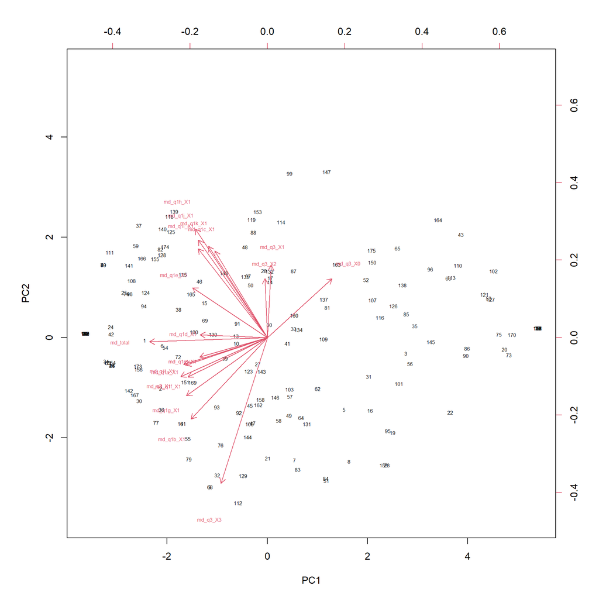

```r
biplot(mdPCA, scale = 0, cex = 0.5)
```

# Question 3 Support Vector Machine (SVM)

We will apply the SVM to classify attempted suicide. We will conduct linear, non-linear (radial basis kernel, polynomial basis kernel) SVM. Since there’s an imbalance distribution for the target variable (approximately 30% attempted suicide), we will oversample the minority class by 50% (replacement = TRUE) in order to see if that can boost up the model performance. Finally, we will apply PCA and then conduct the SVM on the subset (reduced dimensions from original data) to see if there’s any improvement. Since there are 13 missing values from the suicide variable, we will remove those individuals and look at the complete set only.

## data prep

We will transform the target variable into factor before passing it to the SVM algorithm. We will create a different train set by oversampling the minority class (attempted suicide equal to “Yes”) for comparison. Every model/confusion matrix denoted to “2” is from the oversampling train set.

```r
# let's remove the missing suicide data and look at the complete data set
dfReady2 <- dfReady[!is.na(df$suicide), ]

# baseline distribution
print("baseline distribution for target variable from entire data set:")
```

```
## [1] "baseline distribution for target variable from entire data set:"
```

```r
table(dfReady2 %>%
          dplyr::mutate(suicide_X1 = dplyr::case_when(suicide_X1 >0 ~1, TRUE ~0) %>%
                          factor(., levels = c("1", "0"), labels = c("Yes", "No"))) %>%
          dplyr::select(suicide_X1))
```

```
##
## Yes  No
##  49 113
```

```r
# split data
set.seed(1234)
index <- floor(sample(1:nrow(dfReady2), nrow(dfReady2) * .75, replace = FALSE))
trainSet <- dfReady2[index, ] %>% dplyr::mutate(suicide_X1 = dplyr::case_when(suicide_X1 >0 ~1, TRUE ~0) %>%
                                                   factor(., levels = c("1", "0"), labels = c("Yes", "No")))
testSet <- dfReady2[-index, ] %>% dplyr::mutate(suicide_X1 = dplyr::case_when(suicide_X1 >0 ~1, TRUE ~0) %>%
                                                   factor(., levels = c("1", "0"), labels = c("Yes", "No")))

# oversampling the minority class
set.seed(1234)
oversampling_by = 1.5
oversample_index = sample(1:nrow(trainSet %>% dplyr::filter(suicide_X1 == "Yes")),
                          floor(nrow(trainSet %>% dplyr::filter(suicide_X1 == "Yes")) * oversampling_by),
                          replace = TRUE)

trainSet2 = dplyr::bind_rows(
    trainSet %>% dplyr::filter(suicide_X1 == "Yes") %>%
        .[oversample_index, ],
    trainSet %>% dplyr::filter(suicide_X1 == "No")
    )

# trainSetControl
trainSet.control <- caret::trainControl(method = "repeatedcv",
                                        number = 10,
                                        summaryFunction = twoClassSummary,
                                        classProb = TRUE)
#trainSet.control <- caret::trainControl(method = "cv", number = 5, savePredictions = "final", classProbs = TRUE)

# distribution from train, test sets
print("distribution of target variable from train set:")
```

```
## [1] "distribution of target variable from train set:"
```

```r
table(trainSet$suicide_X1)
```

```
##
## Yes  No
##  36  85
```

```r
# distribution from train, test sets
print("distribution of target variable from oversample train set:")
```

```
## [1] "distribution of target variable from oversample train set:"
```

```r
table(trainSet2$suicide_X1)
```

```
##
## Yes  No
##  54  85
```

```r
print("distribution of target variable from test set:")
```

```
## [1] "distribution of target variable from test set:"
```

```r
table(testSet$suicide_X1)
```

```
##
## Yes  No
##  13  28
```

## SVM linear

By default, **caret** builds the SVM linear classifier using C = 1. This tuning parameter C, also known as **Cost**, determines the possible misclassification. Essentially, it imposes a penalty to the model for making an error, i.e. the higher value of C, the less likely it is that the SVM algorithm will misclassify a target.

### linear

```r
set.seed(12)
svm_lin <- caret::train(suicide_X1 ~.,
                        data = trainSet,
                        method = "svmLinear",
                        trControl = trainSet.control,
                        tuneGrid = expand.grid(C = seq(0.1, 2, length = 20)),
                        metric = "ROC")

svm_lin2 <- caret::train(suicide_X1 ~.,
                        data = trainSet2,
                        method = "svmLinear",
                        trControl = trainSet.control,
                        tuneGrid = expand.grid(C = seq(0.1, 2, length = 20)),
                        metric = "ROC")

# overview of the model
print("regular train set:")
```

```
## [1] "regular train set:"
```

```r
svm_lin
```

```
## Support Vector Machines with Linear Kernel
##
## 121 samples
## 141 predictors
##   2 classes: 'Yes', 'No'
##
## No pre-processing
## Resampling: Cross-Validated (10 fold, repeated 1 times)
## Summary of sample sizes: 109, 109, 109, 109, 109, 109, ...
## Resampling results across tuning parameters:
##
##   C    ROC        Sens        Spec
##   0.1  0.7236111  0.15000000  0.9291667
##   0.2  0.7204861  0.17500000  0.8930556
##   0.3  0.7204861  0.17500000  0.9416667
##   0.4  0.7204861  0.02500000  0.9416667
##   0.5  0.7204861  0.15000000  0.9166667
##   0.6  0.7204861  0.20833333  0.9180556
##   0.7  0.7204861  0.15833333  0.9291667
##   0.8  0.7204861  0.07500000  0.9291667
##   0.9  0.7204861  0.07500000  0.9319444
##   1.0  0.7204861  0.18333333  0.9055556
##   1.1  0.7204861  0.15833333  0.9180556
##   1.2  0.7204861  0.17500000  0.9180556
##   1.3  0.7204861  0.21666667  0.9194444
##   1.4  0.7204861  0.09166667  0.9305556
##   1.5  0.7204861  0.22500000  0.9069444
##   1.6  0.7204861  0.15833333  0.9430556
##   1.7  0.7204861  0.15833333  0.9305556
##   1.8  0.7204861  0.15833333  0.9416667
##   1.9  0.7204861  0.12500000  0.9416667
##   2.0  0.7204861  0.13333333  0.9305556
##
## ROC was used to select the optimal model using the largest value.
## The final value used for the model was C = 0.1.
```

```r
print("oversample train set:")
```

```
## [1] "oversample train set:"
```

```r
svm_lin2
```

```
## Support Vector Machines with Linear Kernel
##
## 139 samples
## 141 predictors
##   2 classes: 'Yes', 'No'
##
## No pre-processing
## Resampling: Cross-Validated (10 fold, repeated 1 times)
## Summary of sample sizes: 126, 124, 125, 124, 125, 124, ...
## Resampling results across tuning parameters:
##
##   C    ROC        Sens  Spec
##   0.1  0.8967593  0.84  0.8694444
##   0.2  0.8967593  0.82  0.8694444
##   0.3  0.8967593  0.82  0.8694444
##   0.4  0.8967593  0.84  0.8583333
##   0.5  0.8967593  0.82  0.8694444
##   0.6  0.8967593  0.82  0.8583333
##   0.7  0.8967593  0.84  0.8694444
##   0.8  0.8967593  0.84  0.8583333
##   0.9  0.8967593  0.84  0.8583333
##   1.0  0.8967593  0.82  0.8583333
##   1.1  0.8967593  0.82  0.8694444
##   1.2  0.8967593  0.82  0.8361111
##   1.3  0.8967593  0.82  0.8583333
##   1.4  0.8967593  0.82  0.8694444
##   1.5  0.8967593  0.82  0.8583333
##   1.6  0.8967593  0.84  0.8694444
##   1.7  0.8967593  0.84  0.8583333
##   1.8  0.8967593  0.84  0.8694444
##   1.9  0.8967593  0.82  0.8694444
##   2.0  0.8967593  0.84  0.8694444
##
## ROC was used to select the optimal model using the largest value.
## The final value used for the model was C = 0.1.
```

### confusion matrix: linear

```r
# testSet
cm_svm_lin = caret::confusionMatrix(predict(svm_lin, testSet, type = "raw"), testSet$suicide_X1)
cm_svm_lin2 = caret::confusionMatrix(predict(svm_lin2, testSet, type = "raw"), testSet$suicide_X1)

print("regular train set:")
```

```
## [1] "regular train set:"
```

```r
cm_svm_lin
```

```
## Confusion Matrix and Statistics
##
##           Reference
## Prediction Yes No
##        Yes   8 11
##        No    5 17
##
##                Accuracy : 0.6098
##                  95% CI : (0.445, 0.758)
##     No Information Rate : 0.6829
##     P-Value [Acc > NIR] : 0.8788
##
##                   Kappa : 0.198
##
##  Mcnemar's Test P-Value : 0.2113
##
##             Sensitivity : 0.6154
##             Specificity : 0.6071
##          Pos Pred Value : 0.4211
##          Neg Pred Value : 0.7727
##              Prevalence : 0.3171
##          Detection Rate : 0.1951
##    Detection Prevalence : 0.4634
##       Balanced Accuracy : 0.6113
##
##        'Positive' Class : Yes
##
```

```r
print("oversample train set:")
```

```
## [1] "oversample train set:"
```

```r
cm_svm_lin2
```

```
## Confusion Matrix and Statistics
##
##           Reference
## Prediction Yes No
##        Yes   7  7
##        No    6 21
##
##                Accuracy : 0.6829
##                  95% CI : (0.5191, 0.8192)
##     No Information Rate : 0.6829
##     P-Value [Acc > NIR] : 0.5744
##
##                   Kappa : 0.2826
##
##  Mcnemar's Test P-Value : 1.0000
##
##             Sensitivity : 0.5385
##             Specificity : 0.7500
##          Pos Pred Value : 0.5000
##          Neg Pred Value : 0.7778
##              Prevalence : 0.3171
##          Detection Rate : 0.1707
##    Detection Prevalence : 0.3415
##       Balanced Accuracy : 0.6442
##
##        'Positive' Class : Yes
##
```

## SVM non-linear

### non-linear: radial kernel

```r
set.seed(12)
svm_k <- caret::train(suicide_X1 ~.,
                      data = trainSet,
                      method = "svmRadial",
                      trControl = trainSet.control,
                      # tuneGrid = expand.grid(sigma = 2^c(-25, -20, -15,-10, -5, 0),
                      #                        C = 2^c(0:5))
                      tuneLength = 10,
                      metric = "ROC")

svm_k2 <- caret::train(suicide_X1 ~.,
                      data = trainSet2,
                      method = "svmRadial",
                      trControl = trainSet.control,
                      # tuneGrid = expand.grid(sigma = 2^c(-25, -20, -15,-10, -5, 0),
                      #                        C = 2^c(0:5))
                      tuneLength = 10,
                      metric = "ROC")

# overview of the model
print("regular train set:")
```

```
## [1] "regular train set:"
```

```r
svm_k
```

```
## Support Vector Machines with Radial Basis Function Kernel
##
## 121 samples
## 141 predictors
##   2 classes: 'Yes', 'No'
##
## No pre-processing
## Resampling: Cross-Validated (10 fold, repeated 1 times)
## Summary of sample sizes: 109, 109, 109, 109, 109, 109, ...
## Resampling results across tuning parameters:
##
##   C       ROC        Sens       Spec
##     0.25  0.7408565  0.2000000  0.8958333
##     0.50  0.7408565  0.3583333  0.8722222
##     1.00  0.7408565  0.2166667  0.8958333
##     2.00  0.7535880  0.2833333  0.9208333
##     4.00  0.7466435  0.1333333  0.9319444
##     8.00  0.7378472  0.1750000  0.9194444
##    16.00  0.7378472  0.2250000  0.9333333
##    32.00  0.7378472  0.1500000  0.9444444
##    64.00  0.7378472  0.2500000  0.9444444
##   128.00  0.7378472  0.2000000  0.9666667
##
## Tuning parameter 'sigma' was held constant at a value of 0.003861466
## ROC was used to select the optimal model using the largest value.
## The final values used for the model were sigma = 0.003861466 and C = 2.
```

```r
print("oversample train set:")
```

```
## [1] "oversample train set:"
```

```r
svm_k2
```

```
## Support Vector Machines with Radial Basis Function Kernel
##
## 139 samples
## 141 predictors
##   2 classes: 'Yes', 'No'
##
## No pre-processing
## Resampling: Cross-Validated (10 fold, repeated 1 times)
## Summary of sample sizes: 125, 125, 125, 125, 125, 124, ...
## Resampling results across tuning parameters:
##
##   C       ROC        Sens       Spec
##     0.25  0.8919444  0.7433333  0.7791667
##     0.50  0.8919444  0.7833333  0.8277778
##     1.00  0.9040278  0.7233333  0.8361111
##     2.00  0.9278704  0.7600000  0.8944444
##     4.00  0.9333333  0.8133333  0.9305556
##     8.00  0.9407407  0.8133333  0.9416667
##    16.00  0.9407407  0.8133333  0.9305556
##    32.00  0.9407407  0.8300000  0.9430556
##    64.00  0.9407407  0.8133333  0.9430556
##   128.00  0.9407407  0.8300000  0.9305556
##
## Tuning parameter 'sigma' was held constant at a value of 0.003823617
## ROC was used to select the optimal model using the largest value.
## The final values used for the model were sigma = 0.003823617 and C = 8.
```

### confusion matrix: radial kernel

```r
cm_svm_k = caret::confusionMatrix(predict(svm_k, testSet, type = "raw"), testSet$suicide_X1)
cm_svm_k2 = caret::confusionMatrix(predict(svm_k2, testSet, type = "raw"), testSet$suicide_X1)

print("regular train set:")
```

```
## [1] "regular train set:"
```

```r
cm_svm_k
```

```
## Confusion Matrix and Statistics
##
##           Reference
## Prediction Yes No
##        Yes   1  1
##        No   12 27
##
##                Accuracy : 0.6829
##                  95% CI : (0.5191, 0.8192)
##     No Information Rate : 0.6829
##     P-Value [Acc > NIR] : 0.574381
##
##                   Kappa : 0.0533
##
##  Mcnemar's Test P-Value : 0.005546
##
##             Sensitivity : 0.07692
##             Specificity : 0.96429
##          Pos Pred Value : 0.50000
##          Neg Pred Value : 0.69231
##              Prevalence : 0.31707
##          Detection Rate : 0.02439
##    Detection Prevalence : 0.04878
##       Balanced Accuracy : 0.52060
##
##        'Positive' Class : Yes
##
```

```r
print("oversamle train set:")
```

```
## [1] "oversamle train set:"
```

```r
cm_svm_k2
```

```
## Confusion Matrix and Statistics
##
##           Reference
## Prediction Yes No
##        Yes   3  3
##        No   10 25
##
##                Accuracy : 0.6829
##                  95% CI : (0.5191, 0.8192)
##     No Information Rate : 0.6829
##     P-Value [Acc > NIR] : 0.57438
##
##                   Kappa : 0.1445
##
##  Mcnemar's Test P-Value : 0.09609
##
##             Sensitivity : 0.23077
##             Specificity : 0.89286
##          Pos Pred Value : 0.50000
##          Neg Pred Value : 0.71429
##              Prevalence : 0.31707
##          Detection Rate : 0.07317
##    Detection Prevalence : 0.14634
##       Balanced Accuracy : 0.56181
##
##        'Positive' Class : Yes
##
```

### non-linear: polynomial kernel

```r
set.seed(12)
svm_p <- caret::train(suicide_X1 ~.,
                      data = trainSet,
                      method = "svmPoly",
                      trControl = trainSet.control,
                      tuneLength = 5,
                      metric = "ROC")

svm_p2 <- caret::train(suicide_X1 ~.,
                       data = trainSet2,
                       method = "svmPoly",
                       trControl = trainSet.control,
                       tuneLength = 5,
                       metric = "ROC")

# overview of the model
print("regular train set:")
```

```
## [1] "regular train set:"
```

```r
svm_p
```

```
## Support Vector Machines with Polynomial Kernel
##
## 121 samples
## 141 predictors
##   2 classes: 'Yes', 'No'
##
## No pre-processing
## Resampling: Cross-Validated (10 fold, repeated 1 times)
## Summary of sample sizes: 109, 109, 109, 109, 109, 109, ...
## Resampling results across tuning parameters:
##
##   degree  scale  C     ROC        Sens        Spec
##   1       1e-03  0.25  0.7733796  0.35833333  0.8722222
##   1       1e-03  0.50  0.7733796  0.26666667  0.8847222
##   1       1e-03  1.00  0.7733796  0.45000000  0.8361111
```

[output cut: 75 more lines]

```r
print("oversample train set:")
```

```
## [1] "oversample train set:"
```

```r
svm_p2
```

```
## Support Vector Machines with Polynomial Kernel
##
## 139 samples
## 141 predictors
##   2 classes: 'Yes', 'No'
##
## No pre-processing
## Resampling: Cross-Validated (10 fold, repeated 1 times)
## Summary of sample sizes: 126, 124, 124, 125, 125, 126, ...
## Resampling results across tuning parameters:
##
##   degree  scale  C     ROC        Sens       Spec
##   1       1e-03  0.25  0.8583333  0.6966667  0.7500000
##   1       1e-03  0.50  0.8583333  0.7333333  0.7625000
##   1       1e-03  1.00  0.8583333  0.6933333  0.7388889
```

[output cut: 75 more lines]

### confusion matrix: polynomial kernel

```r
cm_svm_p = caret::confusionMatrix(predict(svm_p, testSet, type = "raw"), testSet$suicide_X1)
cm_svm_p2 = caret::confusionMatrix(predict(svm_p2, testSet, type = "raw"), testSet$suicide_X1)

print("regular train set:")
```

```
## [1] "regular train set:"
```

```r
cm_svm_p
```

```
## Confusion Matrix and Statistics
##
##           Reference
## Prediction Yes No
##        Yes   5 10
##        No    8 18
##
##                Accuracy : 0.561
##                  95% CI : (0.3975, 0.7153)
##     No Information Rate : 0.6829
##     P-Value [Acc > NIR] : 0.9648
##
##                   Kappa : 0.0264
##
##  Mcnemar's Test P-Value : 0.8137
##
##             Sensitivity : 0.3846
##             Specificity : 0.6429
##          Pos Pred Value : 0.3333
##          Neg Pred Value : 0.6923
##              Prevalence : 0.3171
##          Detection Rate : 0.1220
##    Detection Prevalence : 0.3659
##       Balanced Accuracy : 0.5137
##
##        'Positive' Class : Yes
##
```

```r
print("oversample train set:")
```

```
## [1] "oversample train set:"
```

```r
cm_svm_p2
```

```
## Confusion Matrix and Statistics
##
##           Reference
## Prediction Yes No
##        Yes   1  0
##        No   12 28
##
##                Accuracy : 0.7073
##                  95% CI : (0.5446, 0.8387)
##     No Information Rate : 0.6829
##     P-Value [Acc > NIR] : 0.441471
##
##                   Kappa : 0.1022
##
##  Mcnemar's Test P-Value : 0.001496
##
##             Sensitivity : 0.07692
##             Specificity : 1.00000
##          Pos Pred Value : 1.00000
##          Neg Pred Value : 0.70000
##              Prevalence : 0.31707
##          Detection Rate : 0.02439
##    Detection Prevalence : 0.02439
##       Balanced Accuracy : 0.53846
##
##        'Positive' Class : Yes
##
```

## SVM result (without PCA)

```r
cmResultList = list(cm_svm_lin, cm_svm_lin2, cm_svm_k, cm_svm_k2, cm_svm_p, cm_svm_p2)
names(cmResultList) <- wrapr::qc(cm_svm_lin, cm_svm_lin2, cm_svm_k, cm_svm_k2, cm_svm_p, cm_svm_p2)

cmResultDf = lapply(1:length(cmResultList), function(x) broom::tidy(cmResultList[[x]]) %>%
                        dplyr::mutate(type = names(cmResultList)[x]) %>%
                        dplyr::filter(term != "mcnemar") %>%
                        dplyr::select(type, term, estimate)) %>%
    dplyr::bind_rows() %>%
    tidyr::spread(type, estimate) %>%
    dplyr::select(term, cm_svm_lin, cm_svm_lin2, cm_svm_k, cm_svm_k2, cm_svm_p, cm_svm_p2)

cmResultDf %>% mutate_if(is.numeric, round, digits = 2) %>% kable()
```

| term | cm_svm_lin | cm_svm_lin2 | cm_svm_k | cm_svm_k2 | cm_svm_p | cm_svm_p2 |
| --- | --- | --- | --- | --- | --- | --- |
| accuracy | 0.61 | 0.68 | 0.68 | 0.68 | 0.56 | 0.71 |
| balanced_accuracy | 0.61 | 0.64 | 0.52 | 0.56 | 0.51 | 0.54 |
| detection_prevalence | 0.46 | 0.34 | 0.05 | 0.15 | 0.37 | 0.02 |
| detection_rate | 0.20 | 0.17 | 0.02 | 0.07 | 0.12 | 0.02 |
| f1 | 0.50 | 0.52 | 0.13 | 0.32 | 0.36 | 0.14 |
| kappa | 0.20 | 0.28 | 0.05 | 0.14 | 0.03 | 0.10 |
| neg_pred_value | 0.77 | 0.78 | 0.69 | 0.71 | 0.69 | 0.70 |
| pos_pred_value | 0.42 | 0.50 | 0.50 | 0.50 | 0.33 | 1.00 |
| precision | 0.42 | 0.50 | 0.50 | 0.50 | 0.33 | 1.00 |
| prevalence | 0.32 | 0.32 | 0.32 | 0.32 | 0.32 | 0.32 |
| recall | 0.62 | 0.54 | 0.08 | 0.23 | 0.38 | 0.08 |
| sensitivity | 0.62 | 0.54 | 0.08 | 0.23 | 0.38 | 0.08 |
| specificity | 0.61 | 0.75 | 0.96 | 0.89 | 0.64 | 1.00 |

## SVM with PCA

### PCA

Let’s apply PCA on entire data set (minus the initial, suicide and psych_meds variables). Two things to bear in mind. First, we should not combine the train and test set to obtain PCA components of entire data set at once for building a model. This would violate the assumption of generalization since test data would be part of the training set. Second, we should not perform PCA on test and train data sets separately. It’s because the resultant vectors from train and test PCA will have different directions due to unequal variance. We would end up comparing data registered on different axes. The resulting vectors from train and test data should have same axes.

Below, we perform PCA on entire data using the train set only. Subsequently, we use it to “predict” or generate the scores vector using the test set. We extract the first 42 PC only - the standard deviations above 1 and together they explain more than 82% of the total variance in the entire data.

In other words, we use these 42 principal components extracted from the original data set to generate new train and test set to classify attempted suicide.

```r
allPCA <- prcomp(trainSet %>% dplyr::select(-suicide_X1))
summary(allPCA)
```

```
## Importance of components:
##                           PC1     PC2     PC3     PC4     PC5     PC6     PC7
## Standard deviation     4.0942 2.97246 2.62241 2.35121 2.06964 1.95840 1.90525
## Proportion of Variance 0.1196 0.06306 0.04908 0.03945 0.03057 0.02737 0.02591
## Cumulative Proportion  0.1196 0.18268 0.23176 0.27122 0.30178 0.32916 0.35506
##                            PC8     PC9    PC10    PC11    PC12    PC13    PC14
## Standard deviation     1.85771 1.79661 1.75481 1.74476 1.68986 1.62378 1.60874
## Proportion of Variance 0.02463 0.02304 0.02198 0.02173 0.02038 0.01882 0.01847
## Cumulative Proportion  0.37969 0.40273 0.42470 0.44643 0.46681 0.48562 0.50409
##                           PC15    PC16   PC17    PC18    PC19    PC20    PC21
## Standard deviation     1.55995 1.54894 1.5341 1.49389 1.48107 1.44552 1.43752
## Proportion of Variance 0.01737 0.01712 0.0168 0.01593 0.01565 0.01491 0.01475
## Cumulative Proportion  0.52146 0.53858 0.5554 0.57130 0.58696 0.60187 0.61662
##                           PC22    PC23    PC24    PC25    PC26    PC27    PC28
## Standard deviation     1.39840 1.37149 1.34159 1.33747 1.32528 1.28853 1.27217
## Proportion of Variance 0.01396 0.01342 0.01284 0.01277 0.01253 0.01185 0.01155
## Cumulative Proportion  0.63057 0.64400 0.65684 0.66961 0.68214 0.69399 0.70554
##                           PC29   PC30    PC31    PC32    PC33    PC34    PC35
## Standard deviation     1.23957 1.2186 1.21005 1.19935 1.17526 1.17023 1.15915
## Proportion of Variance 0.01097 0.0106 0.01045 0.01027 0.00986 0.00977 0.00959
## Cumulative Proportion  0.71651 0.7271 0.73756 0.74782 0.75768 0.76745 0.77704
##                          PC36    PC37    PC38    PC39    PC40    PC41    PC42
## Standard deviation     1.1356 1.11785 1.09176 1.07148 1.06702 1.04077 1.02170
## Proportion of Variance 0.0092 0.00892 0.00851 0.00819 0.00813 0.00773 0.00745
## Cumulative Proportion  0.7862 0.79516 0.80367 0.81186 0.81999 0.82772 0.83517
##                           PC43    PC44   PC45   PC46    PC47    PC48    PC49
## Standard deviation     0.99524 0.98927 0.9690 0.9469 0.94174 0.92200 0.90368
## Proportion of Variance 0.00707 0.00698 0.0067 0.0064 0.00633 0.00607 0.00583
## Cumulative Proportion  0.84223 0.84922 0.8559 0.8623 0.86865 0.87471 0.88054
##                           PC50    PC51    PC52    PC53    PC54    PC55    PC56
## Standard deviation     0.89555 0.88769 0.87526 0.84160 0.81559 0.81206 0.80074
## Proportion of Variance 0.00572 0.00562 0.00547 0.00505 0.00475 0.00471 0.00458
## Cumulative Proportion  0.88627 0.89189 0.89736 0.90241 0.90716 0.91186 0.91644
##                          PC57   PC58    PC59    PC60    PC61    PC62    PC63
## Standard deviation     0.7855 0.7761 0.76094 0.74308 0.71082 0.69707 0.69135
## Proportion of Variance 0.0044 0.0043 0.00413 0.00394 0.00361 0.00347 0.00341
## Cumulative Proportion  0.9208 0.9251 0.92927 0.93321 0.93682 0.94029 0.94370
##                           PC64   PC65    PC66   PC67    PC68   PC69   PC70
## Standard deviation     0.68536 0.6479 0.64605 0.6377 0.62308 0.6031 0.5914
## Proportion of Variance 0.00335 0.0030 0.00298 0.0029 0.00277 0.0026 0.0025
```

[output cut: 18 more lines]

```
## Standard deviation     0.22356 0.2057 0.18717 0.16468 0.15958 0.15394 0.13917
## Proportion of Variance 0.00036 0.0003 0.00025 0.00019 0.00018 0.00017 0.00014
## Cumulative Proportion  0.99824 0.9985 0.99879 0.99898 0.99917 0.99934 0.99947
##                          PC106   PC107   PC108   PC109   PC110   PC111   PC112
## Standard deviation     0.12832 0.12216 0.09780 0.08741 0.08355 0.06800 0.06586
## Proportion of Variance 0.00012 0.00011 0.00007 0.00005 0.00005 0.00003 0.00003
## Cumulative Proportion  0.99959 0.99970 0.99977 0.99982 0.99987 0.99990 0.99993
##                          PC113   PC114   PC115   PC116   PC117   PC118    PC119
## Standard deviation     0.05453 0.04987 0.03901 0.03488 0.02293 0.01987 0.009912
## Proportion of Variance 0.00002 0.00002 0.00001 0.00001 0.00000 0.00000 0.000000
## Cumulative Proportion  0.99996 0.99997 0.99998 0.99999 1.00000 1.00000 1.000000
##                           PC120     PC121
## Standard deviation     0.005238 1.818e-15
## Proportion of Variance 0.000000 0.000e+00
## Cumulative Proportion  1.000000 1.000e+00
```

```r
# Creating new train, test set
new_trainSet = trainSet %>%
  dplyr::select(class = suicide_X1) %>%
  dplyr::bind_cols(., allPCA$x[, 1:42] %>% as.data.frame())

new_testSet = dplyr::bind_cols(class = testSet$suicide_X1,
                               predict(allPCA, newdata = testSet)[, 1:42] %>% as.data.frame())

head(new_trainSet) %>% kable() %>% scroll_box()
```

| class | PC1 | PC2 | PC3 | PC4 | PC5 | PC6 | PC7 | PC8 | PC9 | PC10 | PC11 | PC12 | PC13 | PC14 | PC15 | PC16 | PC17 | PC18 | PC19 | PC20 | PC21 | PC22 | PC23 | PC24 | PC25 | PC26 | PC27 | PC28 | PC29 | … |
| --- | --- | --- | --- | --- | --- | --- | --- | --- | --- | --- | --- | --- | --- | --- | --- | --- | --- | --- | --- | --- | --- | --- | --- | --- | --- | --- | --- | --- | --- | --- |
| No | -3.6760325 | 0.9025737 | -0.8533614 | -0.6424059 | 3.1404945 | -2.4068625 | 2.5936024 | -0.2752442 | 2.4375080 | -3.5732779 | 0.3636365 | -1.3158427 | -0.0253694 | 3.510257 | -0.3404633 | 1.1484560 | -1.1293488 | 1.1807501 | -1.0785017 | 0.0940768 | -2.6457249 | 2.6009260 | -1.6474473 | 2.4467312 | -0.2766032 | 3.3520441 | -1.6244012 | 0.8968699 | -1.8947154 | … |
| No | 3.9395325 | 1.0781653 | -2.3074429 | -1.4227203 | 0.5726469 | 2.3669185 | 1.1115195 | 0.6420161 | -0.0626763 | -0.6175299 | -2.0395076 | -0.1053947 | -0.9344130 | 3.182997 | -1.3869283 | 0.8050877 | 1.2263981 | -1.2139514 | -1.6364863 | -1.4750159 | 0.7620168 | -0.0810030 | 0.5340579 | -1.6900442 | -1.4331840 | -0.7600603 | 0.7988899 | 0.4667923 | 0.3129791 | … |
| No | 2.3783464 | 4.0906301 | 1.9318383 | -1.2607047 | 2.7874379 | 1.0125659 | 0.9692229 | -0.6408011 | 1.3695497 | 1.9401024 | -2.3517277 | -0.6695541 | 0.4496061 | 1.582119 | -0.5478429 | 1.2775160 | -3.2914848 | -2.6385285 | -0.1657286 | 0.0223252 | -1.0119377 | 1.9005591 | -0.6078274 | -0.6369560 | 3.7283715 | 2.8320924 | 0.7623110 | 1.0137766 | -0.0739318 | … |
| Yes | -2.8919297 | 0.8055935 | -1.6445421 | -2.6898423 | -0.9577633 | 2.0986306 | -3.1745759 | -1.8499688 | 0.6409800 | -1.8248527 | 3.2954261 | 3.5352988 | 0.3961642 | 1.858608 | 3.3373951 | -1.8453842 | -1.0037627 | -1.2223489 | 0.3350823 | -3.0509225 | 0.8523294 | -0.2325066 | 0.2237014 | -0.4234234 | -0.9219221 | -1.2227752 | -0.6988169 | 0.5957703 | 1.2152458 | … |
| Yes | 1.9202998 | -3.9688377 | 0.6654366 | 4.0675281 | 1.1069558 | 2.2004685 | -0.4839410 | 1.3459804 | -1.3149672 | -1.5532784 | 0.9128973 | -2.6286473 | -2.2295664 | 1.076575 | 1.7195983 | 0.0685811 | -0.3019210 | -0.4820657 | -0.9069369 | 2.4854417 | 0.3608066 | -2.7600764 | -1.0126209 | 1.3659258 | -0.4923310 | 1.7730725 | -0.9884306 | 0.7261298 | -0.8708647 | … |
| No | -0.1707352 | -3.7124216 | 0.6111994 | 0.1622702 | 2.6143553 | -0.3541141 | -1.1687355 | 3.7354806 | 0.7721244 | 0.3320192 | 0.7727093 | -0.9442291 | -0.9183544 | -2.267558 | 1.9535308 | 1.6630558 | 0.6133752 | -1.3685033 | -1.1261747 | 0.0011286 | 2.6344394 | -0.4900578 | 0.1695124 | -0.0260289 | 2.0287634 | -0.0590538 | 1.1855477 | 2.1977099 | -1.5934112 | … |

### linear

```r
set.seed(12)
svm_lin_new <- caret::train(class ~.,
                            data = new_trainSet,
                            method = "svmLinear",
                            trControl = trainSet.control,
                            tuneGrid = expand.grid(C = seq(0.1, 2, length = 20)),
                            metric = "ROC")
svm_lin_new
```

```
## Support Vector Machines with Linear Kernel
##
## 121 samples
##  42 predictor
##   2 classes: 'Yes', 'No'
##
## No pre-processing
## Resampling: Cross-Validated (10 fold, repeated 1 times)
## Summary of sample sizes: 109, 109, 109, 109, 109, 109, ...
## Resampling results across tuning parameters:
##
##   C    ROC        Sens       Spec
##   0.1  0.6510417  0.0500000  0.9416667
##   0.2  0.6726852  0.1833333  0.9180556
##   0.3  0.6922454  0.1250000  0.9416667
##   0.4  0.7000000  0.1500000  0.9638889
##   0.5  0.7062500  0.1750000  0.9416667
##   0.6  0.7068287  0.1833333  0.9277778
##   0.7  0.7099537  0.1583333  0.9541667
##   0.8  0.7093750  0.2083333  0.9166667
##   0.9  0.7125000  0.1583333  0.9291667
##   1.0  0.7152778  0.1583333  0.9166667
##   1.1  0.7109954  0.1916667  0.9291667
##   1.2  0.7135417  0.2666667  0.9055556
##   1.3  0.7041667  0.1833333  0.9291667
##   1.4  0.7004630  0.2333333  0.9291667
##   1.5  0.7041667  0.2916667  0.8958333
##   1.6  0.7032407  0.2666667  0.9055556
##   1.7  0.7104167  0.2333333  0.9166667
##   1.8  0.7131944  0.2333333  0.9166667
##   1.9  0.7159722  0.2333333  0.9180556
##   2.0  0.7230324  0.2416667  0.9083333
##
## ROC was used to select the optimal model using the largest value.
## The final value used for the model was C = 2.
```

```r
cm_svm_lin_new = caret::confusionMatrix(predict(svm_lin_new, new_testSet, type = "raw"), new_testSet$class)
cm_svm_lin_new
```

```
## Confusion Matrix and Statistics
##
##           Reference
## Prediction Yes No
##        Yes   5  4
##        No    8 24
##
##                Accuracy : 0.7073
##                  95% CI : (0.5446, 0.8387)
##     No Information Rate : 0.6829
##     P-Value [Acc > NIR] : 0.4415
##
##                   Kappa : 0.2635
##
##  Mcnemar's Test P-Value : 0.3865
##
##             Sensitivity : 0.3846
##             Specificity : 0.8571
##          Pos Pred Value : 0.5556
##          Neg Pred Value : 0.7500
##              Prevalence : 0.3171
##          Detection Rate : 0.1220
##    Detection Prevalence : 0.2195
##       Balanced Accuracy : 0.6209
##
##        'Positive' Class : Yes
##
```

### radial kernel

```r
set.seed(12)
svm_k_new <- caret::train(class ~.,
                          data = new_trainSet,
                          method = "svmRadial",
                          trControl = trainSet.control,
                          # tuneGrid = expand.grid(sigma = 2^c(-25, -20, -15,-10, -5, 0),
                          #                    C = 2^c(0:5)),
                          tuneLength = 5,
                          metric = "ROC")
svm_k_new
```

```
## Support Vector Machines with Radial Basis Function Kernel
##
## 121 samples
##  42 predictor
##   2 classes: 'Yes', 'No'
##
## No pre-processing
## Resampling: Cross-Validated (10 fold, repeated 1 times)
## Summary of sample sizes: 109, 109, 109, 109, 109, 109, ...
## Resampling results across tuning parameters:
##
##   C     ROC        Sens       Spec
##   0.25  0.7379630  0.2666667  0.8833333
##   0.50  0.7379630  0.1750000  0.9083333
##   1.00  0.7379630  0.2333333  0.9055556
##   2.00  0.7503472  0.1916667  0.9083333
##   4.00  0.7284722  0.2083333  0.9180556
##
## Tuning parameter 'sigma' was held constant at a value of 0.01281921
## ROC was used to select the optimal model using the largest value.
## The final values used for the model were sigma = 0.01281921 and C = 2.
```

```r
cm_svm_k_new = caret::confusionMatrix(predict(svm_k_new, new_testSet, type = "raw"), new_testSet$class)
cm_svm_k_new
```

```
## Confusion Matrix and Statistics
##
##           Reference
## Prediction Yes No
##        Yes   3  4
##        No   10 24
##
##                Accuracy : 0.6585
##                  95% CI : (0.4941, 0.7992)
##     No Information Rate : 0.6829
##     P-Value [Acc > NIR] : 0.6978
##
##                   Kappa : 0.1003
##
##  Mcnemar's Test P-Value : 0.1814
##
##             Sensitivity : 0.23077
##             Specificity : 0.85714
##          Pos Pred Value : 0.42857
##          Neg Pred Value : 0.70588
##              Prevalence : 0.31707
##          Detection Rate : 0.07317
##    Detection Prevalence : 0.17073
##       Balanced Accuracy : 0.54396
##
##        'Positive' Class : Yes
##
```

### polynomial kernel

```r
set.seed(12)
svm_p_new <- caret::train(class ~.,
                          data = new_trainSet,
                          method = "svmPoly",
                          trControl = trainSet.control,
                          tuneLength = 5,
                          metric = "ROC")
svm_p_new
```

```
## Support Vector Machines with Polynomial Kernel
##
## 121 samples
##  42 predictor
##   2 classes: 'Yes', 'No'
##
## No pre-processing
## Resampling: Cross-Validated (10 fold, repeated 1 times)
## Summary of sample sizes: 109, 109, 109, 109, 109, 109, ...
## Resampling results across tuning parameters:
##
##   degree  scale  C     ROC        Sens        Spec
##   1       1e-03  0.25  0.7484954  0.26666667  0.8944444
##   1       1e-03  0.50  0.7438657  0.21666667  0.9194444
##   1       1e-03  1.00  0.7438657  0.35833333  0.8611111
```

[output cut: 75 more lines]

```r
cm_svm_p_new = caret::confusionMatrix(predict(svm_p_new, new_testSet, type = "raw"), new_testSet$class)
cm_svm_p_new
```

```
## Confusion Matrix and Statistics
##
##           Reference
## Prediction Yes No
##        Yes   6  6
##        No    7 22
##
##                Accuracy : 0.6829
##                  95% CI : (0.5191, 0.8192)
##     No Information Rate : 0.6829
##     P-Value [Acc > NIR] : 0.5744
##
##                   Kappa : 0.2525
##
##  Mcnemar's Test P-Value : 1.0000
##
##             Sensitivity : 0.4615
##             Specificity : 0.7857
##          Pos Pred Value : 0.5000
##          Neg Pred Value : 0.7586
##              Prevalence : 0.3171
##          Detection Rate : 0.1463
##    Detection Prevalence : 0.2927
##       Balanced Accuracy : 0.6236
##
##        'Positive' Class : Yes
##
```

## SVM result final

Unfortunately, PCA does not seem to bring significant help. The **SVM linear** is still the best method among all based on f1 score. The **SVM polynomial** with “oversampling” strategy does help to bring precision to 100% but lower sensitivity to 8%. Overall, the linear model (especially with oversampling) achieves moderate success in terms of accuracy, sensitivity, and precision.

```r
cmResultList2 = list(cm_svm_lin_new, cm_svm_k_new, cm_svm_p_new)
names(cmResultList2) <- wrapr::qc(cm_svm_lin_new, cm_svm_k_new, cm_svm_p_new)

cmResultDf2 = lapply(1:length(cmResultList2), function(x) broom::tidy(cmResultList2[[x]]) %>%
                        dplyr::mutate(type = names(cmResultList2)[x]) %>%
                        dplyr::filter(term != "mcnemar") %>%
                        dplyr::select(type, term, estimate)) %>%
    dplyr::bind_rows() %>%
    tidyr::spread(type, estimate) %>%
    dplyr::select(term, cm_svm_lin_new, cm_svm_k_new, cm_svm_p_new)


finalComparison = dplyr::inner_join(cmResultDf, cmResultDf2, by = "term") %>%
    dplyr::select(term,
                  cm_svm_lin, cm_svm_lin2, cm_svm_lin_new,
                  cm_svm_k, cm_svm_k2, cm_svm_k_new,
                  cm_svm_p, cm_svm_p2, cm_svm_p_new)

finalComparison %>% mutate_if(is.numeric, round, digits = 2) %>% kable()
```

| term | cm_svm_lin | cm_svm_lin2 | cm_svm_lin_new | cm_svm_k | cm_svm_k2 | cm_svm_k_new | cm_svm_p | cm_svm_p2 | cm_svm_p_new |
| --- | --- | --- | --- | --- | --- | --- | --- | --- | --- |
| accuracy | 0.61 | 0.68 | 0.71 | 0.68 | 0.68 | 0.66 | 0.56 | 0.71 | 0.68 |
| balanced_accuracy | 0.61 | 0.64 | 0.62 | 0.52 | 0.56 | 0.54 | 0.51 | 0.54 | 0.62 |
| detection_prevalence | 0.46 | 0.34 | 0.22 | 0.05 | 0.15 | 0.17 | 0.37 | 0.02 | 0.29 |
| detection_rate | 0.20 | 0.17 | 0.12 | 0.02 | 0.07 | 0.07 | 0.12 | 0.02 | 0.15 |
| f1 | 0.50 | 0.52 | 0.45 | 0.13 | 0.32 | 0.30 | 0.36 | 0.14 | 0.48 |
| kappa | 0.20 | 0.28 | 0.26 | 0.05 | 0.14 | 0.10 | 0.03 | 0.10 | 0.25 |
| neg_pred_value | 0.77 | 0.78 | 0.75 | 0.69 | 0.71 | 0.71 | 0.69 | 0.70 | 0.76 |
| pos_pred_value | 0.42 | 0.50 | 0.56 | 0.50 | 0.50 | 0.43 | 0.33 | 1.00 | 0.50 |
| precision | 0.42 | 0.50 | 0.56 | 0.50 | 0.50 | 0.43 | 0.33 | 1.00 | 0.50 |
| prevalence | 0.32 | 0.32 | 0.32 | 0.32 | 0.32 | 0.32 | 0.32 | 0.32 | 0.32 |
| recall | 0.62 | 0.54 | 0.38 | 0.08 | 0.23 | 0.23 | 0.38 | 0.08 | 0.46 |
| sensitivity | 0.62 | 0.54 | 0.38 | 0.08 | 0.23 | 0.23 | 0.38 | 0.08 | 0.46 |
| specificity | 0.61 | 0.75 | 0.86 | 0.96 | 0.89 | 0.86 | 0.64 | 1.00 | 0.79 |